# Lab Session 2 - 1.5 Hours

# Convolutional Neural Network (CNN) for Handwritten Digits Recognition

Group members:  
**Youssef AZEBA**  
**Lionel SOME**

The aim of this session is to practice with Convolutional Neural Networks. Each group should fill and run appropriate notebook cells.

Generate your final report (export as HTML) and upload it on the submission website http://bigfoot-m1.eurecom.fr/teachingsub/login (using your deeplearnXX/password). Do not forget to run all your cells before generating your final report and do not forget to include the names of all participants in the group. The lab session should be completed and submitted by May 30th 2018 (23:59:59 CET).

# Introduction

In the previous Lab Session, you built a Multilayer Perceptron for recognizing hand-written digits from the MNIST data-set. The best achieved accuracy on testing data was about 97%. Can you do better than these results using a deep CNN ? In this Lab Session, you will build, train and optimize in TensorFlow one of the early Convolutional Neural Networks, **LeNet-5**, to go to more than 99% of accuracy.

# Load MNIST Data in TensorFlow

Run the cell below to load the MNIST data that comes with TensorFlow. You will use this data in **Section 1** and **Section 2**.

```python
import tensorflow as tf
import numpy as np
import pandas as pd
import time
import matplotlib.pyplot as plt
from tensorflow.examples.tutorials.mnist import input_data
mnist = input_data.read_data_sets("MNIST_data/", one_hot=True)
X_train, y_train           = mnist.train.images, mnist.train.labels
X_validation, y_validation = mnist.validation.images, mnist.validation.labels
X_test, y_test             = mnist.test.images, mnist.test.labels
print("Image Shape: {}".format(X_train[0].shape))
print("Training Set:   {} samples".format(len(X_train)))
print("Validation Set: {} samples".format(len(X_validation)))
print("Test Set:       {} samples".format(len(X_test)))

epsilon = 1e-10 # this is a parameter you will use later
```

```
Extracting MNIST_data/train-images-idx3-ubyte.gz
Extracting MNIST_data/train-labels-idx1-ubyte.gz
Extracting MNIST_data/t10k-images-idx3-ubyte.gz
Extracting MNIST_data/t10k-labels-idx1-ubyte.gz
Image Shape: (784,)
Training Set:   55000 samples
Validation Set: 5000 samples
Test Set:       10000 samples
```

# Section 1 : My First Model in TensorFlow

```python
! pip install tensorflow
```

```
You are using pip version 9.0.1, however version 10.0.1 is available.
```

Before starting with CNN, let's train and test in TensorFlow the example **y=softmax(Wx+b)** seen in the first lab.

This model reaches an accuracy of about 92 %. You will also learn how to launch the TensorBoard https://www.tensorflow.org/get_started/summaries_and_tensorboard to visualize the computation graph, statistics and learning curves.

**Part 1** : Read carefully the code in the cell below. Run it to perform training.

```python
#STEP 1

# Parameters
learning_rate = 0.01
training_epochs = 40
batch_size = 128
display_step = 1
logs_path = 'log_files/'  # useful for tensorboard

# tf Graph Input:  mnist data image of shape 28*28=784
x = tf.placeholder(tf.float32, [None, 784], name='InputData')
# 0-9 digits recognition,  10 classes
y = tf.placeholder(tf.float32, [None, 10], name='LabelData')

# Set model weights
W = tf.Variable(tf.zeros([784, 10]), name='Weights')
b = tf.Variable(tf.zeros([10]), name='Bias')

# Construct model and encapsulating all ops into scopes, making Tensorboard's Graph visualization more convenient
with tf.name_scope('Model'):
    # Model
    pred = tf.nn.softmax(tf.matmul(x, W) + b) # Softmax
with tf.name_scope('Loss'):
    # Minimize error using cross entropy
    # We use tf.clip_by_value to avoid having too low numbers in the log function
    cost = tf.reduce_mean(-tf.reduce_sum(y*tf.log(tf.clip_by_value(pred, epsilon, 1.0)), reduction_indices=1))
with tf.name_scope('SGD'):
    # Gradient Descent
    optimizer = tf.train.GradientDescentOptimizer(learning_rate).minimize(cost)
with tf.name_scope('Accuracy'):
    # Accuracy
    acc = tf.equal(tf.argmax(pred, 1), tf.argmax(y, 1))
    acc = tf.reduce_mean(tf.cast(acc, tf.float32))

# Initializing the variables
init = tf.global_variables_initializer()
# Create a summary to monitor cost tensor
tf.summary.scalar("Loss", cost)
# Create a summary to monitor accuracy tensor
tf.summary.scalar("Accuracy", acc)
# Merge all summaries into a single op
merged_summary_op = tf.summary.merge_all()

#STEP 2

# Launch the graph for training
with tf.Session() as sess:
    sess.run(init)
    # op to write logs to Tensorboard
    summary_writer = tf.summary.FileWriter(logs_path, graph=tf.get_default_graph())
    # Training cycle
    for epoch in range(training_epochs):
        avg_cost = 0.
        total_batch = int(mnist.train.num_examples/batch_size)
        # Loop over all batches
        for i in range(total_batch):
            batch_xs, batch_ys = mnist.train.next_batch(batch_size, shuffle=(i==0))
            # Run optimization op (backprop), cost op (to get loss value)
            # and summary nodes
            _, c, summary = sess.run([optimizer, cost, merged_summary_op],
                                     feed_dict={x: batch_xs, y: batch_ys})
            # Write logs at every iteration
            summary_writer.add_summary(summary, epoch * total_batch + i)
            # Compute average loss
            avg_cost += c / total_batch
        # Display logs per epoch step
        if (epoch+1) % display_step == 0:
            print("Epoch: ", '%02d' % (epoch+1), "  =====> Loss=", "{:.9f}".format(avg_cost))

    print("Optimization Finished!")
    summary_writer.flush()

    # Test model
    # Calculate accuracy
    print("Accuracy:", acc.eval({x: mnist.test.images, y: mnist.test.labels}))
```

```
Epoch:  01   =====> Loss= 1.288747327
Epoch:  02   =====> Loss= 0.732453646
Epoch:  03   =====> Loss= 0.600214283
Epoch:  04   =====> Loss= 0.536855336
Epoch:  05   =====> Loss= 0.497782313
Epoch:  06   =====> Loss= 0.470985515
Epoch:  07   =====> Loss= 0.451345392
Epoch:  08   =====> Loss= 0.435930342
Epoch:  09   =====> Loss= 0.423434887
Epoch:  10   =====> Loss= 0.413006283
Epoch:  11   =====> Loss= 0.404539983
Epoch:  12   =====> Loss= 0.396797512
Epoch:  13   =====> Loss= 0.390423384
Epoch:  14   =====> Loss= 0.384634728
Epoch:  15   =====> Loss= 0.379344575
Epoch:  16   =====> Loss= 0.374674806
Epoch:  17   =====> Loss= 0.370340165
Epoch:  18   =====> Loss= 0.366402250
Epoch:  19   =====> Loss= 0.363089665
Epoch:  20   =====> Loss= 0.359725350
Epoch:  21   =====> Loss= 0.356608236
Epoch:  22   =====> Loss= 0.353645167
Epoch:  23   =====> Loss= 0.351049643
Epoch:  24   =====> Loss= 0.348796715
Epoch:  25   =====> Loss= 0.346479928
Epoch:  26   =====> Loss= 0.344369876
Epoch:  27   =====> Loss= 0.342192750
Epoch:  28   =====> Loss= 0.340433644
Epoch:  29   =====> Loss= 0.338447228
Epoch:  30   =====> Loss= 0.336611090
Epoch:  31   =====> Loss= 0.335195719
Epoch:  32   =====> Loss= 0.333415060
Epoch:  33   =====> Loss= 0.332232270
Epoch:  34   =====> Loss= 0.330580318
Epoch:  35   =====> Loss= 0.329196744
Epoch:  36   =====> Loss= 0.328090003
Epoch:  37   =====> Loss= 0.326855233
Epoch:  38   =====> Loss= 0.325493530
Epoch:  39   =====> Loss= 0.323980874
Epoch:  40   =====> Loss= 0.323326602
Optimization Finished!
Accuracy: 0.9163
```

**Part 2** : Using Tensorboard, we can now visualize the created graph, giving you an overview of your architecture and how all of the major components are connected. You can also see and analyse the learning curves.

To launch tensorBoard:

- Open a Terminal and run the command line **"tensorboard --logdir=lab_2/log_files/"**
- Click on "Tensorboard web interface" in Zoe

Enjoy It !!

TensorFlow's computations being complicated, the graph on tensorboard is powerful and can help us understand and debug them by giving an simple visualization of what's going on.

Now let's see what the learning curves look like:

```python
def plot_curve(acc_pd,t):
    #plot the curve
    plt.figure(figsize=(16,8))
    plt.plot(acc_pd['Wall time'],acc_pd['Value'])
    plt.xlabel('Time')
    plt.ylabel(t[0])
    plt.title(t[0]+ ' evolution of the ' + t[1] +" optimizer")
    plt.grid()
```

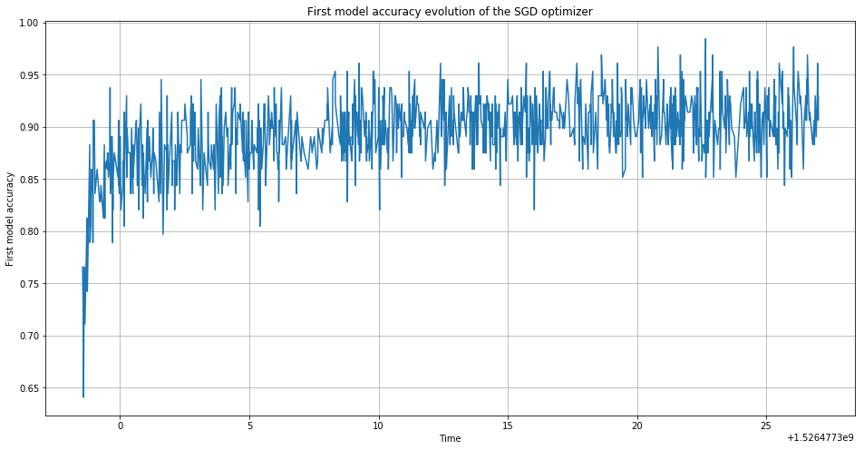

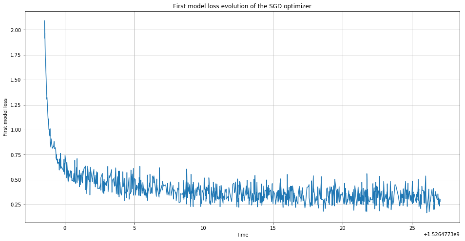

```python
#create a dataframe for the accuracy and loss from the csv files
first_acc_pd=pd.read_csv("log_files/First model_Accuracy_1.csv")
first_loss_pd=pd.read_csv("log_files/First model-Loss_1.csv")

#plot the curves
plot_curve(first_acc_pd,("First model accuracy", "SGD"))
plot_curve(first_loss_pd,("First model loss", "SGD"))
```

We can see that both those learning curves above, for the accuracy and the loss, know a lot of fluctuations and the results aren't very good. Throughout this notebook we will improve those results to get an accuracy of more than 99%.

# Section 2 : The 99% MNIST Challenge !

**Part 1** : LeNet5 implementation

You are now more familar with **TensorFlow** and **TensorBoard**. In this section, you are to build, train and test the baseline [LeNet-5](http://yann.lecun.com/exdb/lenet/) model for the MNIST digits recognition problem.

Then, you will make some optimizations to get more than 99% of accuracy.

For more informations, have a look at this list of results: http://rodrigob.github.io/are_we_there_yet/build/classification_datasets_results.html

The LeNet architecture takes a 28x28xC image as input, where C is the number of color channels. Since MNIST images are grayscale, C is 1 in this case.

**Layer 1 - Convolution (5x5):** The output shape should be 28x28x6. **Activation:** ReLU. **MaxPooling:** The output shape should be 14x14x6.

**Layer 2 - Convolution (5x5):** The output shape should be 10x10x16. **Activation:** ReLU. **MaxPooling:** The output shape should be 5x5x16.

**Flatten:** Flatten the output shape of the final pooling layer such that it's 1D instead of 3D. You may need to use tf.reshape.

**Layer 3 - Fully Connected:** This should have 120 outputs. **Activation:** ReLU.

**Layer 4 - Fully Connected:** This should have 84 outputs. **Activation:** ReLU.

**Layer 5 - Fully Connected:** This should have 10 outputs. **Activation:** softmax.

**Question 2.1.1** Implement the Neural Network architecture described above. For that, your will use classes and functions from https://www.tensorflow.org/api_docs/python/tf/nn.

We give you some helper functions for weigths and bias initilization. Also you can refer to section 1.

```python
# Functions for weigths and bias initilization
def weight_variable(shape):
  initial = tf.truncated_normal(shape, stddev=0.1)
  return tf.Variable(initial)

def bias_variable(shape):
  initial = tf.constant(0., shape=shape)
  return tf.Variable(initial)
```

```python
def LeNet5_Model(image, dropout=False):

    input_layer = tf.reshape(image, shape=[-1, 28, 28, 1])
    #creating the filter for the first layer
    conv1_f=weight_variable([5,5,1,6])
    #initializing the bias
    conv1_b=bias_variable([6])
    #Layer 1 Convolution
    conv1=tf.nn.conv2d(input_layer,filter=conv1_f, strides=[1,1,1,1], padding='SAME')
    #Activation for Layer 1
    activ1=tf.nn.relu(conv1 + conv1_b)
    #Layer 1 Max pooling
    pool1=tf.nn.max_pool(activ1, ksize=[1, 2, 2, 1], strides=[1, 2, 2, 1], padding='SAME')

    #creating the filter for the second layer
    conv2_f=weight_variable([5,5,6,16])
    #initializing the bias
    conv2_b=bias_variable([16])
    #Layer 2 Convolution
    conv2=tf.nn.conv2d(pool1,filter=conv2_f, strides=[1,1,1,1], padding='VALID')
    #Activation
    activ2=tf.nn.relu(conv2 + conv2_b)
    #Layer 2 Max pooling
    pool2=tf.nn.max_pool(activ2, ksize=[1, 2, 2, 1], strides=[1, 2, 2, 1], padding='SAME')
    #print("pool2 shape", pool2.shape)

    #compute dropout if dropout=True
    if dropout:
        pool2= tf.nn.dropout(pool2, keep_prob = 0.5)

    #Fully connected 1 (Layer 3) initializing the weights
    fc1_W = weight_variable([5*5*16, 120])
    #Fully connected 1 (Layer 3) initializing the bias
    fc1_b = bias_variable([120])
    #Fully connected 1 (Layer 3) - activation
    fc1_h = tf.nn.relu(tf.matmul(tf.reshape(pool2, shape=[-1, 5*5*16]), fc1_W) + fc1_b)

    #Fully connected 2 (Layer 4) initializing the weights
    fc2_W = weight_variable([120, 84])
    #Fully connected 2 (Layer 4) initializing the bias
    fc2_b = bias_variable([84])
    #Fully connected 2 (Layer 4) - activation
    fc2_h = tf.nn.relu(tf.matmul(fc1_h, fc2_W) + fc2_b)

    #Fully connected 3 (Layer 5) initializing the weights
    fc3_W = weight_variable([84, 10])
    #Fully connected 3 (Layer 5) initializing the bias
    fc3_b = bias_variable([10])
    #Fully connected 3 (Layer 5) - activation
    fc3_h = tf.matmul(fc2_h, fc3_W) + fc3_b

    return fc3_h
```

**Question 2.1.2.** Calculate the number of parameters of this model

NB: The $+1$ in each formula is due to the bias.

**Question 2.1.3.** Define your model, its accuracy and the loss function according to the following parameters (you can look at Section 1 to see what is expected):

```
 Learning rate: 0.001
 Loss Fucntion: Cross-entropy
 Optimizer: tf.train.GradientDescentOptimizer
 Number of epochs: 40
 Batch size: 128
```

```python
tf.reset_default_graph() # reset the default graph before defining a new model

# Parameters
learning_rate = 0.001
training_epochs = 40
batch_size = 128
logs_path = 'MNIST_figures/'

display_step = 10

# Model, loss function and accuracy
# tf Graph Input:  mnist data image of shape 28*28=784
x = tf.placeholder(tf.float32, shape=[None, 784], name='InputData')
# 0-9 digits recognition,  10 classes
y = tf.placeholder(tf.float32, [None, 10], name='LabelData')
```

**Question 2.1.4.** Implement the evaluation function for accuracy computation

```python
def evaluate(logits, labels):
    # logits will be the outputs of your model, labels will be one-hot vectors corresponding to the actual labels
    # logits and labels are numpy arrays
    # this function should return the accuracy of your model

    with tf.name_scope('Accuracy'):
        # Accuracy
        acc = tf.equal(tf.argmax(logits, 1), tf.argmax(labels, 1))
        acc = tf.reduce_mean(tf.cast(acc, tf.float32))
    return acc
```

```python
# Construct model and encapsulating all ops into scopes, making Tensorboard's Graph visualization more convenient
with tf.name_scope('Model'):
    # Model
    pred = LeNet5_Model(x, dropout=False) # LeNet5 Model
    #print("X shape", x.shape)
with tf.name_scope('Loss'):
    # Minimize error using cross entropy
    cost = tf.reduce_mean(tf.nn.softmax_cross_entropy_with_logits(labels=y, logits=pred))
with tf.name_scope('SGD'):
    # Gradient Descent optimizer
    optimizer = tf.train.GradientDescentOptimizer(learning_rate).minimize(cost)
# Accuracy
acc=evaluate(pred, y)
```

**Question 2.1.5.** Implement training pipeline and run the training data through it to train the model.

- Before each epoch, shuffle the training set.
- Print the loss per mini batch and the training/validation accuracy per epoch. (Display results every 100 epochs)
- Save the model after training
- Print after training the final testing accuracy

```python
# Initializing the variables
init = tf.global_variables_initializer()
# Create a summary to monitor cost tensor
tf.summary.scalar("Loss_LeNet-5_SGD", cost)
# Create a summary to monitor accuracy tensor
tf.summary.scalar("Accuracy_LeNet-5_SGD", acc)
# Merge all summaries into a single op
merged_summary_op = tf.summary.merge_all()


def train(init, sess, logs_path, n_epochs, batch_size, optimizer, cost, merged_summary_op):

    # optimizer and cost are the same kinds of objects as in Section 1
        sess.run(init)
        # op to write logs to Tensorboard
        summary_writer = tf.summary.FileWriter(logs_path, graph=tf.get_default_graph())
        # Training cycle
        for epoch in range(training_epochs):
            avg_cost = 0.
            total_batch = int(mnist.train.num_examples/batch_size)
            # Loop over all batches
            for i in range(total_batch):
                batch_xs, batch_ys = mnist.train.next_batch(batch_size, shuffle=(i==0))

                # Run optimization op (backprop), cost op (to get loss value)
                # and summary nodes
                _, c, summary = sess.run([optimizer, cost, merged_summary_op],
                                         feed_dict={x: batch_xs, y: batch_ys})
                # Write logs at every iteration
                summary_writer.add_summary(summary, epoch * total_batch + i)
                # Compute average loss
                avg_cost += c / total_batch
            # Display logs per epoch step
            if (epoch+1) % display_step == 0:
                print("Epoch: ", '%02d' % (epoch+1), "  =====> Loss=", "{:.9f}".format(avg_cost))
            print("Accuracy for Epoch",(epoch+1), 'is:', acc.eval({x: mnist.test.images, y: mnist.test.labels}))


        print("Optimization Finished!")
        summary_writer.flush()

        # Print the accuracy on testing data
        print("Final accuracy:", acc.eval({x: mnist.test.images, y: mnist.test.labels}))

start=time.time()
with tf.Session() as sess:
    train(init, sess, logs_path, training_epochs, batch_size, optimizer, cost, merged_summary_op)
end=time.time()
print("The execution time using the Gradient Descent optimizer is", end-start, "s")
```

```
Accuracy for Epoch 1 is: 0.1588
Accuracy for Epoch 2 is: 0.2377
Accuracy for Epoch 3 is: 0.2798
Accuracy for Epoch 4 is: 0.3499
Accuracy for Epoch 5 is: 0.5676
Accuracy for Epoch 6 is: 0.7355
Accuracy for Epoch 7 is: 0.8134
Accuracy for Epoch 8 is: 0.8486
Accuracy for Epoch 9 is: 0.868
Epoch:  10   =====> Loss= 0.469469959
Accuracy for Epoch 10 is: 0.8822
Accuracy for Epoch 11 is: 0.8943
Accuracy for Epoch 12 is: 0.9013
Accuracy for Epoch 13 is: 0.9079
Accuracy for Epoch 14 is: 0.912
Accuracy for Epoch 15 is: 0.9168
Accuracy for Epoch 16 is: 0.9201
Accuracy for Epoch 17 is: 0.9227
Accuracy for Epoch 18 is: 0.9266
Accuracy for Epoch 19 is: 0.9286
Epoch:  20   =====> Loss= 0.254222786
Accuracy for Epoch 20 is: 0.9306
Accuracy for Epoch 21 is: 0.9331
Accuracy for Epoch 22 is: 0.9349
Accuracy for Epoch 23 is: 0.9386
Accuracy for Epoch 24 is: 0.9399
Accuracy for Epoch 25 is: 0.9407
Accuracy for Epoch 26 is: 0.9419
Accuracy for Epoch 27 is: 0.9441
Accuracy for Epoch 28 is: 0.9444
Accuracy for Epoch 29 is: 0.9466
Epoch:  30   =====> Loss= 0.189569012
Accuracy for Epoch 30 is: 0.9485
Accuracy for Epoch 31 is: 0.949
Accuracy for Epoch 32 is: 0.95
Accuracy for Epoch 33 is: 0.9511
Accuracy for Epoch 34 is: 0.9522
Accuracy for Epoch 35 is: 0.9532
Accuracy for Epoch 36 is: 0.9537
Accuracy for Epoch 37 is: 0.9545
Accuracy for Epoch 38 is: 0.9554
Accuracy for Epoch 39 is: 0.9563
Epoch:  40   =====> Loss= 0.154469021
Accuracy for Epoch 40 is: 0.9568
Optimization Finished!
Final accuracy: 0.9568
The execution time using the Gradient Descent optimizer is 861.30126953125 s
```

**Question 2.1.6** : Use TensorBoard to visualise and save loss and accuracy curves. You will save figures in the folder **"lab_2/MNIST_figures"** and display them in your notebook.

We downloaded and imported the corresponding csv files to both the loss and accuracy data so that we could easily plot them.

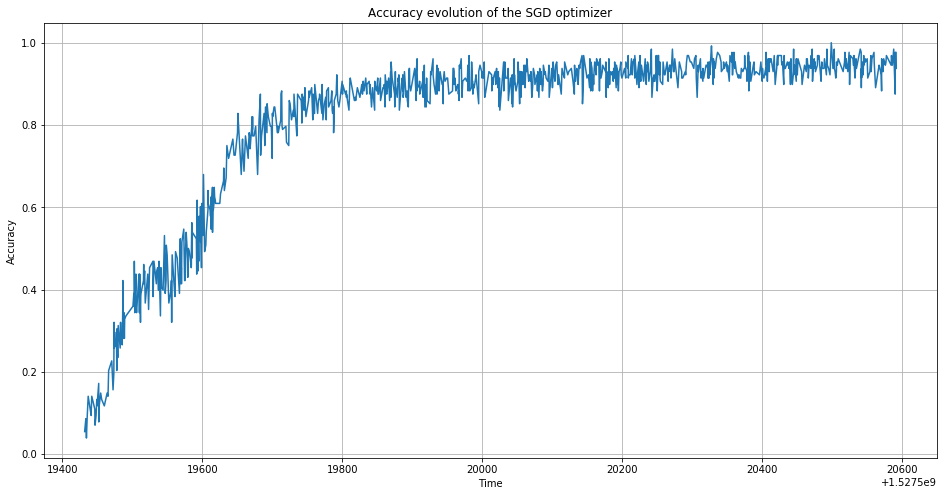

```python
#read the accuracy csv file in a pandas dataframe
acc_pd=pd.read_csv('./MNIST_figures/Accuracy_LeNet-5_SGD.csv')
#plot the curve
plot_curve(acc_pd,('Accuracy','SGD'))
```

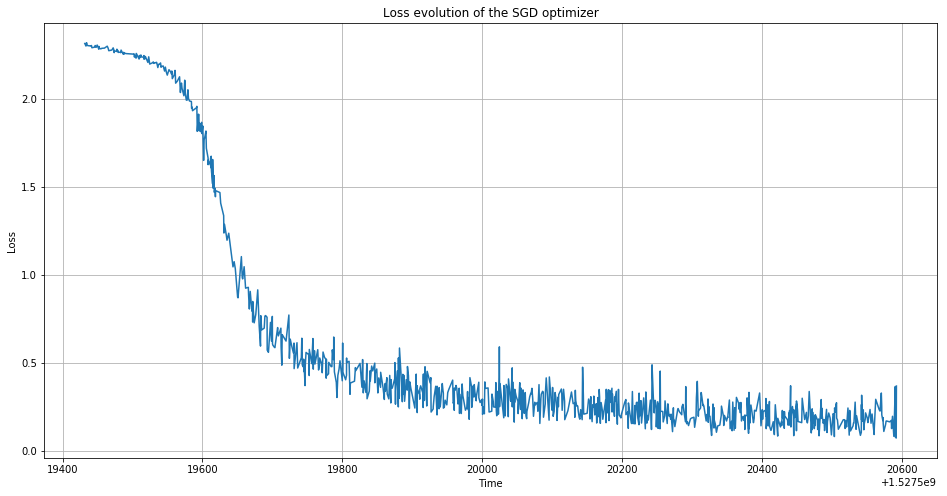

```python
#read the loss csv file in a pandas dataframe
loss_pd=pd.read_csv('./MNIST_figures/Loss_LeNet-5_SGD.csv')

#plot the curve
plot_curve(loss_pd,('Loss','SGD'))
```

**Comment :**  
As we can see from the shape of the figure above, the accuracy and the loss take time to converge. This is typical of SGD for which the convergence depends on the learning rate. Choosing a good value for the learning rate is a very important step when using the SGD.  
However, we decided to use and keep the learning rate of 0.001 because it gives quite good results. We could have tried to play with different values of the learning rate but we needed to find a trade off between time and good accuracy.  
Unfortunately, we didn't reach the 99% accuracy with this implementation.  
Let's see if it will get better with AdamOptimizer.

# Part 2 : LeNET 5 Optimization

**Question 2.2.1**

- Retrain your network with AdamOptimizer and then fill the table below:
- Which optimizer gives the best accuracy on test data?

| Optimizer | Gradient Descent | AdamOptimizer |
| --- | --- | --- |
| Testing Accuracy | 0.9568 | 0.9888 |
| Training Time | 861,30s | 868.39 s |

**Your answer:**

The tf.train.AdamOptimizer uses Kingma and Ba's Adam algorithm to control the learning rate. Adam offers several advantages over the simple tf.train.GradientDescentOptimizer. Foremost is that it uses moving averages of the parameters (momentum); Simply put, this enables Adam to use a larger effective step size, and the algorithm will converge to this step size without fine tuning.  
The main down side of the algorithm is that Adam requires more computation (therefore in general more time) to be performed for each parameter in each training step (to maintain the moving averages and variance, and calculate the scaled gradient); and more state to be retained for each parameter (approximately tripling the size of the model to store the average and variance for each parameter). Since in our case the dataset size is not that big, the difference between the two training time is negligible but AdamOptimizer accuracy is much better. Therefore, it's a really good trade off in our case between time and accuracy.

```python
tf.reset_default_graph()
# Parameters
learning_rate = 0.001
training_epochs = 40
batch_size = 128
logs_path = 'Adam_optimizer/'

display_step = 1

# Model, loss function and accuracy
# tf Graph Input:  mnist data image of shape 28*28=784
x = tf.placeholder(tf.float32, shape=[None, 784], name='InputData')
# 0-9 digits recognition,  10 classes
y = tf.placeholder(tf.float32, [None, 10], name='LabelData')

# Construct model and encapsulating all ops into scopes, making Tensorboard's Graph visualization more convenient
with tf.name_scope('Model'):
    # Model
    pred = LeNet5_Model(x) # LeNet5 Model
    #print("X shape", x.shape)
with tf.name_scope('Loss'):
    # Minimize error using cross entropy
    cost = tf.reduce_mean(tf.nn.softmax_cross_entropy_with_logits(labels=y, logits=pred))
with tf.name_scope('Adam'):
    # Adam optimizer
    optimizer = tf.train.AdamOptimizer(learning_rate).minimize(cost)
# Accuracy
acc=evaluate(pred, y)

# Initializing the variables
init = tf.global_variables_initializer()
# Create a summary to monitor cost tensor
tf.summary.scalar("Loss_LeNet-5_Adam", cost)
# Create a summary to monitor accuracy tensor
tf.summary.scalar("Accuracy_LeNet-5_Adam", acc)
# Merge all summaries into a single op
merged_summary_op = tf.summary.merge_all()
start=time.time()
with tf.Session() as sess:
    train(init, sess, logs_path, training_epochs, batch_size, optimizer, cost, merged_summary_op)
end=time.time()
print("The execution time using the Adam optimizer is", end-start, "s")
```

```
Epoch:  01   =====> Loss= 0.340137796
Accuracy for Epoch 1 is: 0.9696
Epoch:  02   =====> Loss= 0.093737120
Accuracy for Epoch 2 is: 0.9787
Epoch:  03   =====> Loss= 0.067912964
Accuracy for Epoch 3 is: 0.9839
Epoch:  04   =====> Loss= 0.053379927
Accuracy for Epoch 4 is: 0.9853
Epoch:  05   =====> Loss= 0.044111682
Accuracy for Epoch 5 is: 0.9861
Epoch:  06   =====> Loss= 0.036398883
Accuracy for Epoch 6 is: 0.9868
Epoch:  07   =====> Loss= 0.030853053
Accuracy for Epoch 7 is: 0.9869
Epoch:  08   =====> Loss= 0.027632036
Accuracy for Epoch 8 is: 0.9864
Epoch:  09   =====> Loss= 0.024103545
Accuracy for Epoch 9 is: 0.9857
Epoch:  10   =====> Loss= 0.022253182
Accuracy for Epoch 10 is: 0.9874
Epoch:  11   =====> Loss= 0.017937757
Accuracy for Epoch 11 is: 0.987
Epoch:  12   =====> Loss= 0.014846447
Accuracy for Epoch 12 is: 0.9866
Epoch:  13   =====> Loss= 0.013908278
Accuracy for Epoch 13 is: 0.9852
Epoch:  14   =====> Loss= 0.015092714
Accuracy for Epoch 14 is: 0.9828
Epoch:  15   =====> Loss= 0.010731896
Accuracy for Epoch 15 is: 0.9856
Epoch:  16   =====> Loss= 0.012167320
Accuracy for Epoch 16 is: 0.9836
Epoch:  17   =====> Loss= 0.010416542
Accuracy for Epoch 17 is: 0.987
Epoch:  18   =====> Loss= 0.008616954
Accuracy for Epoch 18 is: 0.9862
Epoch:  19   =====> Loss= 0.007883674
Accuracy for Epoch 19 is: 0.9871
Epoch:  20   =====> Loss= 0.008218318
Accuracy for Epoch 20 is: 0.9886
```

[output cut: 28 more lines]

```
Epoch:  35   =====> Loss= 0.004983180
Accuracy for Epoch 35 is: 0.9877
Epoch:  36   =====> Loss= 0.003850053
Accuracy for Epoch 36 is: 0.989
Epoch:  37   =====> Loss= 0.002307747
Accuracy for Epoch 37 is: 0.9894
Epoch:  38   =====> Loss= 0.006620950
Accuracy for Epoch 38 is: 0.9899
Epoch:  39   =====> Loss= 0.004897235
Accuracy for Epoch 39 is: 0.9912
Epoch:  40   =====> Loss= 0.001865235
Accuracy for Epoch 40 is: 0.9888
Optimization Finished!
Final accuracy: 0.9888
The execution time using the Adam optimizer is 868.3980827331543 s
```

```python
def LeNet5_Model_Dropout(image):
    #computes dropout before the first fully connected layer
    LeNet5_Model(image, dropout=True)

tf.reset_default_graph()

# Parameters
learning_rate = 0.001
training_epochs = 60
batch_size = 128
logs_path = 'Adam_drop/'

display_step = 1

# Model, loss function and accuracy
# tf Graph Input:  mnist data image of shape 28*28=784
x = tf.placeholder(tf.float32, shape=[None, 784], name='InputData')
# 0-9 digits recognition,  10 classes
y = tf.placeholder(tf.float32, [None, 10], name='LabelData')

# Construct model and encapsulating all ops into scopes, making Tensorboard's Graph visualization more convenient
with tf.name_scope('Model'):
    # Model
    pred = LeNet5_Model(x) # LeNet5 Model
    #print("X shape", x.shape)
with tf.name_scope('Loss'):
    # Minimize error using cross entropy
    cost = tf.reduce_mean(tf.nn.softmax_cross_entropy_with_logits(labels=y, logits=pred))
with tf.name_scope('AdamD'):
    # Adam optimizer
    optimizer = tf.train.AdamOptimizer(learning_rate).minimize(cost)
# Accuracy
acc=evaluate(pred, y)

# Initializing the variables
init = tf.global_variables_initializer()
# Create a summary to monitor cost tensor
tf.summary.scalar("Loss_LeNet-5_AdamD", cost)
# Create a summary to monitor accuracy tensor
tf.summary.scalar("Accuracy_LeNet-5_AdamD", acc)
# Merge all summaries into a single op
merged_summary_op = tf.summary.merge_all()

with tf.Session() as sess:
    train(init, sess, logs_path, training_epochs, batch_size, optimizer, cost, merged_summary_op)
```

```
Epoch:  01   =====> Loss= 0.323681666
Accuracy for Epoch 1 is: 0.9696
Epoch:  02   =====> Loss= 0.092452508
Accuracy for Epoch 2 is: 0.9772
Epoch:  03   =====> Loss= 0.065441900
Accuracy for Epoch 3 is: 0.9819
Epoch:  04   =====> Loss= 0.051878950
Accuracy for Epoch 4 is: 0.9852
Epoch:  05   =====> Loss= 0.043169550
Accuracy for Epoch 5 is: 0.9861
Epoch:  06   =====> Loss= 0.035486287
Accuracy for Epoch 6 is: 0.9859
Epoch:  07   =====> Loss= 0.029453813
Accuracy for Epoch 7 is: 0.9853
Epoch:  08   =====> Loss= 0.025598296
Accuracy for Epoch 8 is: 0.9856
Epoch:  09   =====> Loss= 0.022771088
Accuracy for Epoch 9 is: 0.9856
Epoch:  10   =====> Loss= 0.019084475
Accuracy for Epoch 10 is: 0.9857
Epoch:  11   =====> Loss= 0.017702752
Accuracy for Epoch 11 is: 0.9909
Epoch:  12   =====> Loss= 0.015181500
Accuracy for Epoch 12 is: 0.9897
Epoch:  13   =====> Loss= 0.015159005
Accuracy for Epoch 13 is: 0.9883
Epoch:  14   =====> Loss= 0.013278938
Accuracy for Epoch 14 is: 0.9901
Epoch:  15   =====> Loss= 0.011225796
Accuracy for Epoch 15 is: 0.9897
Epoch:  16   =====> Loss= 0.009536985
Accuracy for Epoch 16 is: 0.9873
Epoch:  17   =====> Loss= 0.009585823
Accuracy for Epoch 17 is: 0.9876
Epoch:  18   =====> Loss= 0.010506267
Accuracy for Epoch 18 is: 0.9905
Epoch:  19   =====> Loss= 0.008819385
Accuracy for Epoch 19 is: 0.9896
Epoch:  20   =====> Loss= 0.007942065
Accuracy for Epoch 20 is: 0.9902
```

[output cut: 67 more lines]

```
Accuracy for Epoch 54 is: 0.9914
Epoch:  55   =====> Loss= 0.003730493
Accuracy for Epoch 55 is: 0.991
Epoch:  56   =====> Loss= 0.004655636
Accuracy for Epoch 56 is: 0.988
Epoch:  57   =====> Loss= 0.003509109
Accuracy for Epoch 57 is: 0.9914
Epoch:  58   =====> Loss= 0.000910461
Accuracy for Epoch 58 is: 0.9923
Epoch:  59   =====> Loss= 0.000921017
Accuracy for Epoch 59 is: 0.9915
Epoch:  60   =====> Loss= 0.003054819
Accuracy for Epoch 60 is: 0.9913
Optimization Finished!
Final accuracy: 0.9913
```

[figure not shown]

[figure not shown]

```python
#create a dataframe for the accuracy and loss from the csv files
AD_acc_pd=pd.read_csv("log_files/First model_Accuracy_1.csv")
AD_loss_pd=pd.read_csv("log_files/First model-Loss_1.csv")

#plot the curves
plot_curve(AD_acc_pd,("Dropout regularization accuracy", "Adam"))
plot_curve(AD_loss_pd,("Dropout regularization loss", "Adam"))
```